# Materials towards Homework 3: LIME with XGBoost & SVM

Part of the **eXplainable Machine Learning** course for Machine Learning (MSc) studies at the University of Warsaw. [@pbiecek](https://github.com/pbiecek) [@hbaniecki](https://github.com/hbaniecki)

v0.1.1: 2022-10-20

https://github.com/mim-uw/eXplainableMachineLearning-2023/tree/main/Homeworks/HW3

## 0. Import packages

```python
import dalex as dx
import xgboost
import lime

import sklearn

import pandas as pd
import numpy as np

import warnings
warnings.filterwarnings("ignore")
```

```python
import platform
print(f'Python {platform.python_version()}')
```

```
Python 3.9.2
```

```python
{package.__name__: package.__version__ for package in [dx, xgboost, sklearn, pd, np]} | {lime.__name__: "0.2.0.1"}
```

```
{'dalex': '1.5.0',
 'xgboost': '1.6.2',
 'sklearn': '1.0.2',
 'pandas': '1.3.5',
 'numpy': '1.22.4',
 'lime': '0.2.0.1'}
```

## 1. Load and preprocess data

`lime.lime_tabular.LimeTabularExplainer` assumes integer-encoded categorical variables by the following [parameters](https://lime-ml.readthedocs.io/en/latest/lime.html#module-lime.lime_tabular):

> **categorical_features** – list of indices (ints) corresponding to the categorical columns. Everything else will be considered continuous. Values in these columns MUST be integers.

> **categorical_names** – map from int to list of names, where categorical_names[x][y] represents the name of the yth value of column x.

But, `XGBoost` assumes categorical variables of strict `category` type.

The challenge is to make one work with the other. First, let's use one-hot encoding.

```python
df = dx.datasets.load_titanic()

X = df.drop(columns='survived')
X = pd.get_dummies(X, columns=['gender', 'class', 'embarked'], drop_first=True)
y = df.survived
```

## 2. Model

We use the same XGBoost classifier as in the previous [materials towards Homework 2](https://github.com/mim-uw/eXplainableMachineLearning-2023/blob/main/Materials/hw2_shap_with_xgboost_on_titanic.html).

```python
model = xgboost.XGBClassifier(
    n_estimators=200,
    max_depth=4,
    use_label_encoder=False,
    eval_metric="logloss"
)

model.fit(X, y)
```

```
XGBClassifier(base_score=0.5, booster='gbtree', callbacks=None,
              colsample_bylevel=1, colsample_bynode=1, colsample_bytree=1,
              early_stopping_rounds=None, enable_categorical=False,
              eval_metric='logloss', gamma=0, gpu_id=-1,
              grow_policy='depthwise', importance_type=None,
              interaction_constraints='', learning_rate=0.300000012,
              max_bin=256, max_cat_to_onehot=4, max_delta_step=0, max_depth=4,
              max_leaves=0, min_child_weight=1, missing=nan,
              monotone_constraints='()', n_estimators=200, n_jobs=0,
              num_parallel_tree=1, predictor='auto', random_state=0,
              reg_alpha=0, reg_lambda=1, ...)
```

## 3. Explain with dalex & lime

[`dalex`](https://python.drwhy.ai) uses the original [`lime`](https://github.com/marcotcr/lime) package to estimate LIME under a unified API.

`dalex` aims to improve the user's conveninence by:

1. combining the use of `LimeTabularExplainer` and `explain_instance()` into the one `predict_surrogate()` method,
2. automatically setting some of the `lime` parameters based on `explainer.data`, `explainer.model_type` etc.

```python
explainer = dx.Explainer(model, X, y)
```

```
Preparation of a new explainer is initiated

  -> data              : 2207 rows 14 cols
  -> target variable   : Parameter 'y' was a pandas.Series. Converted to a numpy.ndarray.
  -> target variable   : 2207 values
  -> model_class       : xgboost.sklearn.XGBClassifier (default)
  -> label             : Not specified, model's class short name will be used. (default)
  -> predict function  : <function yhat_proba_default at 0x000002A96356B940> will be used (default)
  -> predict function  : Accepts pandas.DataFrame and numpy.ndarray.
  -> predicted values  : min = 0.00022, mean = 0.322, max = 1.0
  -> model type        : classification will be used (default)
  -> residual function : difference between y and yhat (default)
  -> residuals         : min = -0.809, mean = -8.27e-05, max = 0.959
  -> model_info        : package xgboost

A new explainer has been created!
```

Check performance on train data

```python
explainer.model_performance(cutoff=y.mean())
```

|  | recall | precision | f1 | accuracy | auc |
| --- | --- | --- | --- | --- | --- |
| XGBClassifier | 0.787623 | 0.851064 | 0.818115 | 0.887177 | 0.944357 |

Explain a prediction of interest

```python
observation = X.iloc[[0]]
explainer.predict(observation)
```

```
array([0.01038458], dtype=float32)
```

```python
explanation = explainer.predict_surrogate(observation)
```

In `dalex` API, the estimated explanation can be accessed via the `result` attribute

```python
explanation.result
```

|  | variable | effect |
| --- | --- | --- |
| 0 | class_deck crew <= 0.00 | -0.234861 |
| 1 | class_restaurant staff <= 0.00 | 0.144448 |
| 2 | 0.00 < class_3rd <= 1.00 | -0.132443 |
| 3 | embarked_Cherbourg <= 0.00 | -0.094520 |
| 4 | age > 38.00 | -0.083834 |
| 5 | sibsp <= 0.00 | 0.074970 |
| 6 | embarked_Queenstown <= 0.00 | 0.052523 |
| 7 | class_victualling crew <= 0.00 | 0.038948 |
| 8 | class_2nd <= 0.00 | 0.033706 |
| 9 | class_engineering crew <= 0.00 | -0.011709 |

Analogously, the estimated explanation can be visualized using the `plot()` method, which uses `as_pyplot_figure()` from `lime`

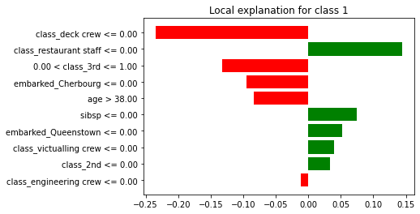

```python
explanation.plot()
```

**Be careful! LIME algorithm, like many other explanations, involves randomness**

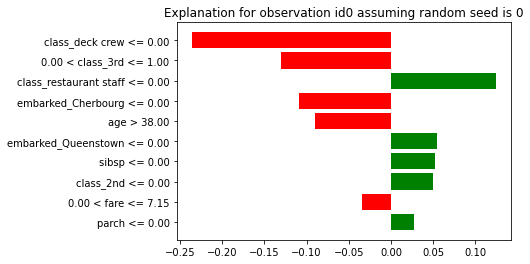

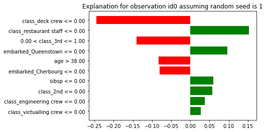

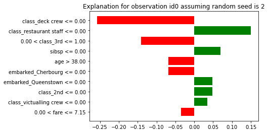

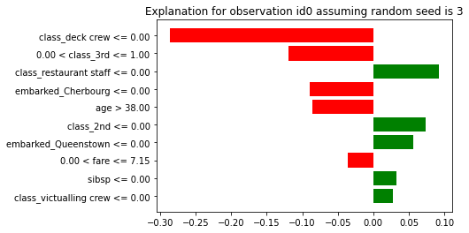

```python
import random
import matplotlib.pyplot as plt

for seed in range(4):
    random.seed(seed)
    np.random.seed(seed)
    exp = explainer.predict_surrogate(observation)
    exp.plot(return_figure=True)
    plt.title(f'Explanation for observation id0 assuming random seed is {seed}')
```

Both [`LimeTabularExplainer`](https://lime-ml.readthedocs.io/en/latest/lime.html#lime.lime_tabular.LimeTabularExplainer) and [`explain_instance()`](https://lime-ml.readthedocs.io/en/latest/lime.html#lime.lime_tabular.LimeTabularExplainer.explain_instance) have many parameters, which can be jointly passed to the [`predict_surrogate()`](https://dalex.drwhy.ai/python/api/#dalex.Explainer.predict_surrogate) interface

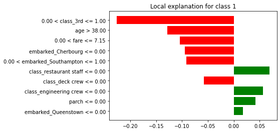

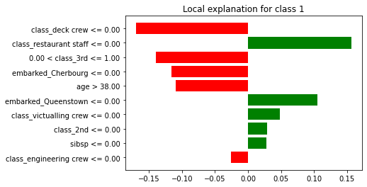

```python
random.seed(0)
np.random.seed(0)
exp_manhattan = explainer.predict_surrogate(observation, num_samples=1000, distance_metric="manhattan", kernel_width=1)
random.seed(0)
np.random.seed(0)
exp_euclidean = explainer.predict_surrogate(observation, num_samples=1000, distance_metric="euclidean", kernel_width=1)
exp_manhattan.plot()
exp_euclidean.plot()
```

## 4. Explain with lime

An example of the same process using the `lime` package

Note that `training_data` needs to be of `numpy` class

```python
lime_explainer = lime.lime_tabular.LimeTabularExplainer(
    training_data=X.values,
    feature_names=X.columns,
    mode="classification"
)
```

```python
lime_explanation = lime_explainer.explain_instance(
    data_row=observation.iloc[0],
    predict_fn=lambda d: model.predict_proba(d)
)
```

```python
lime_explanation.as_list()
```

```
[('class_deck crew <= 0.00', -0.23918294815608596),
 ('class_restaurant staff <= 0.00', 0.162568079624797),
 ('0.00 < class_3rd <= 1.00', -0.1435698690099299),
 ('age > 38.00', -0.07811232716634249),
 ('class_2nd <= 0.00', 0.07459643879945656),
 ('embarked_Cherbourg <= 0.00', -0.06029276614220415),
 ('0.00 < fare <= 7.15', -0.03669565753466026),
 ('embarked_Queenstown <= 0.00', 0.02902459257869579),
 ('sibsp <= 0.00', 0.02600488136435894),
 ('0.00 < embarked_Southampton <= 1.00', 0.020576109367271223)]
```

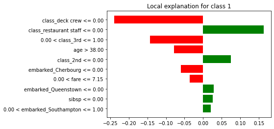

```python
_ = lime_explanation.as_pyplot_figure()
```

```python
_ = lime_explanation.show_in_notebook()
```

#### Now, let's try combining categorical encoding in `xgboost` with an integer encoding in `lime`.

We start by creating two datasets of different type

```python
# convert gender to binary only because the `max_cat_to_onehot` parameter in XGBoost is yet to be working properly..

X_cat = pd.get_dummies(df.drop(columns='survived'), columns=["gender"], drop_first=True)
X_fact = pd.get_dummies(df.drop(columns='survived'), columns=["gender"], drop_first=True)

X_cat.loc[:, X_cat.dtypes == 'object'] =\
    X_cat.select_dtypes(['object'])\
    .apply(lambda x: x.astype('category'))

X_fact.loc[:, X_fact.dtypes == 'object'] =\
    X_cat.select_dtypes(['category'])\
        .apply(lambda x: x.cat.codes)

y = df.survived
```

We use the first dataset to model

```python
model_categorical = xgboost.XGBClassifier(
    n_estimators=200,
    max_depth=4,
    use_label_encoder=False,
    eval_metric="logloss",

    enable_categorical=True,
    tree_method="hist"
)

model_categorical.fit(X_cat, y)
```

```
XGBClassifier(base_score=0.5, booster='gbtree', callbacks=None,
              colsample_bylevel=1, colsample_bynode=1, colsample_bytree=1,
              early_stopping_rounds=None, enable_categorical=True,
              eval_metric='logloss', gamma=0, gpu_id=-1,
              grow_policy='depthwise', importance_type=None,
              interaction_constraints='', learning_rate=0.300000012,
              max_bin=256, max_cat_to_onehot=4, max_delta_step=0, max_depth=4,
              max_leaves=0, min_child_weight=1, missing=nan,
              monotone_constraints='()', n_estimators=200, n_jobs=0,
              num_parallel_tree=1, predictor='auto', random_state=0,
              reg_alpha=0, reg_lambda=1, ...)
```

We use the second dataset to explain

```python
categorical_features = [1, 2]
categorical_names = {id: X_cat.iloc[:, id].cat.categories for id in categorical_features}

print(categorical_names)

lime_explainer = lime.lime_tabular.LimeTabularExplainer(
    training_data=X_fact.values,
    feature_names=X_fact.columns,
    mode="classification",
    categorical_features=categorical_features,
    categorical_names=categorical_names
)
```

```
{1: Index(['1st', '2nd', '3rd', 'deck crew', 'engineering crew',
       'restaurant staff', 'victualling crew'],
      dtype='object'), 2: Index(['Belfast', 'Cherbourg', 'Queenstown', 'Southampton'], dtype='object')}
```

```python
lime_explanation = lime_explainer.explain_instance(
    data_row=X_fact.values[0],
    predict_fn=lambda d: model_categorical.predict_proba(d)
)

lime_explanation.as_list()
```

```
[('class=3rd', -0.25814334719328047),
 ('sibsp <= 0.00', 0.04341223784846835),
 ('age > 38.00', -0.03630740220045356),
 ('0.00 < fare <= 7.15', 0.022511203740082565),
 ('parch <= 0.00', 0.014509941048029574),
 ('embarked=Southampton', -0.010480402013100477),
 ('gender_male <= 1.00', 0.0)]
```

```python
lime_explanation.show_in_notebook()
```

Note that XGBoost allows predicting on both datasets without returning any error..

```python
(model_categorical.predict_proba(X_cat) == model_categorical.predict_proba(X_fact)).mean()
```

```
1.0
```

# 5. Compare with SVM

Working with other models is similar in both packages; the key is a proper `predict_function` in `dalex` and `predict_fn` in `lime`

```python
from sklearn.svm import SVC

svm_ohe = SVC(probability=True)

svm_ohe.fit(X, y)

explainer_svm = dx.Explainer(svm_ohe, X, label="SVM", verbose=False)

explanation_svm = explainer_svm.predict_surrogate(observation)
```

Compare predictions and their explanations

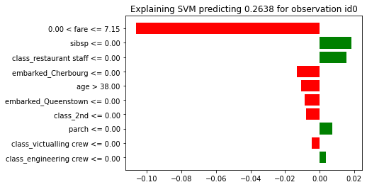

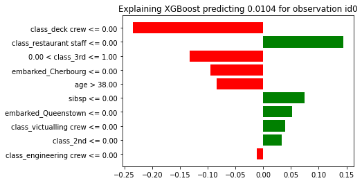

```python
explanation_svm.plot(return_figure=True)
_ = plt.title(f'Explaining SVM predicting {np.round(explainer_svm.predict(observation).item(), 4)} for observation id0')

explanation.plot(return_figure=True)
_ = plt.title(f'Explaining XGBoost predicting {np.round(explainer.predict(observation).item(), 4)} for observation id0')
```

# For a theoretical introduction and more examples, see: https://ema.drwhy.ai